# Fourth Week: Hypothesis Testing

TIMSS Analysis

Kimia Hamidieh (95109434)

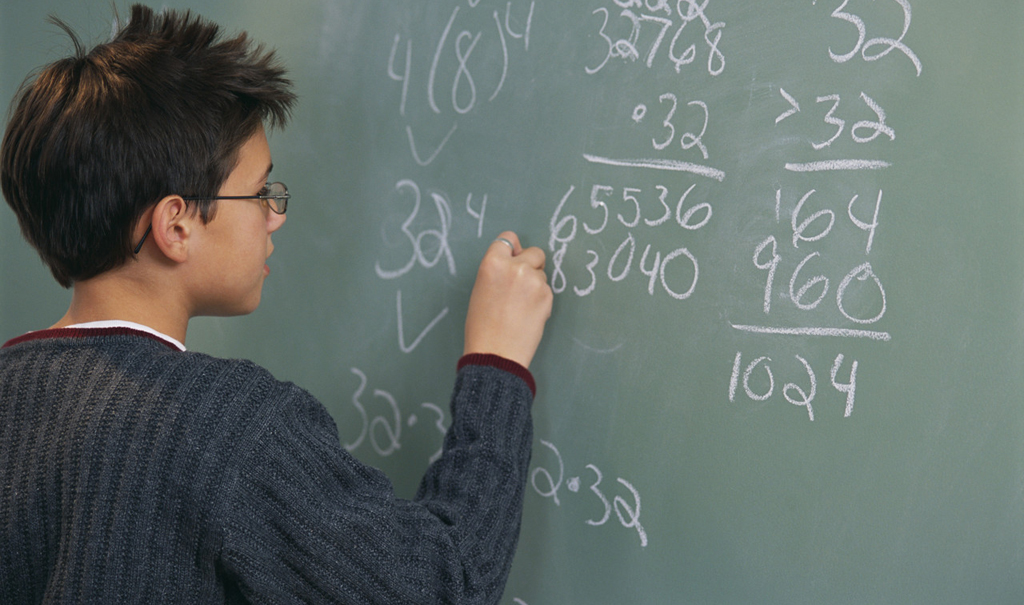

# تمرین سری چهارم: چقدر ریاضی بلدیم و چرا؟

لطفا مقاله زیر را مطالعه بفرمایید.

[چرایی رتبه ضعیف ایران در آزمون تیمز](https://goo.gl/gX8DZc)

> با استفاده از داده های ارزیابی تیمز ۲۰۱۵ ادعاهای زیر را مورد ارزیابی قراردهید. برای هر سوال علاوه بر استدلال آماری که در غالب آزمون فرض تعریف می شود از تصویرسازی مناسب باهر دو ابزار ggplot2 و highcharter استفاده نمایید. به دلخواه به هفت گزاره از موارد زیر پاسخ دهید.

```r
library("readr")
library("dplyr")
library("tidyr")
library("highcharter")
library("ggplot2")

bcg = read_rds("../data/bcg.rds") # school
bsg = read_rds("../data/bsg.rds") # student background
btm = read_rds("../data/btm.rds") # teacher background - math
bts = read_rds("../data/bts.rds") # teacher background - science
bsa = read_rds("../data/bsa.rds") # results
bst = read_rds("../data/bst.rds") # student teacher linkage
```

ابتدا برای بررسی عملکرد دانش آموزان، با استفاده از bsa و میانگین ستون های مربوط به ریاضی و علوم و سپس میانگین این دو، دیتافریمی ایجاد می کنیم.

```r
std_perf = bsa %>% select(idcntry:idstud, bsmmat01:bssrea05)
std_perf %>%
  rowwise() %>%
  mutate(math = mean(c(bsmmat01:bsmmat05))) %>%
  mutate(science = mean(c(bsssci01:bsssci05))) %>%
  mutate(total = mean(c(math, science))) -> std_perf
```

۱. میران رضایت معلمان در پیشرفت تحصیلی دانش آموزان موثر است.

```r
# math ---------------
satxperf_math = full_join(bst %>% select(idcntry:idtealin),
                     std_perf %>% select(idcntry:idstud, math))
satxperf_math = full_join(satxperf_math, btm %>% select(idcntry:idlink, btbg10a:btbg10g))

satxperf_math %>%
  drop_na() %>%
  mutate(sat = 35 - (btbg10a + btbg10b + btbg10c + btbg10d + btbg10e + btbg10f + btbg10g)) %>%
  select(score = math, sat) -> satxperf_math

cor.test(satxperf_math$score, satxperf_math$sat)
```

```
##
##  Pearson's product-moment correlation
##
## data:  satxperf_math$score and satxperf_math$sat
## t = -7.1962, df = 266190, p-value = 6.208e-13
## alternative hypothesis: true correlation is not equal to 0
## 95 percent confidence interval:
##  -0.01774450 -0.01014825
## sample estimates:
##         cor
## -0.01394658
```

```r
# science ---------------
satxperf_sci = full_join(bst %>% select(idcntry:idtealin),
                          std_perf %>% select(idcntry:idstud, science))
satxperf_sci = full_join(satxperf_sci, bts %>% select(idcntry:idlink, btbg10a:btbg10g))

satxperf_sci %>%
  drop_na() %>%
  mutate(sat = 35 - (btbg10a + btbg10b + btbg10c + btbg10d + btbg10e + btbg10f + btbg10g)) %>%
  select(score = science, sat) -> satxperf_sci

cor.test(satxperf_sci$score, satxperf_sci$sat)
```

```
##
##  Pearson's product-moment correlation
##
## data:  satxperf_sci$score and satxperf_sci$sat
## t = -7.1062, df = 375980, p-value = 1.195e-12
## alternative hypothesis: true correlation is not equal to 0
## 95 percent confidence interval:
##  -0.014784416 -0.008392403
## sample estimates:
##         cor
## -0.01158853
```

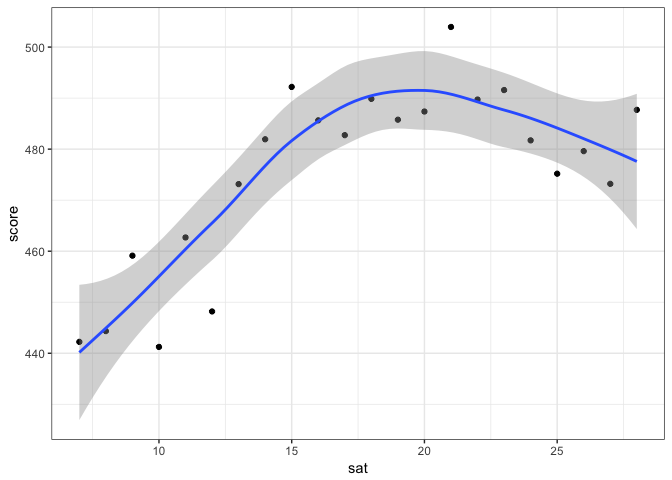

```r
# both ---------------
satxperf = rbind(satxperf_math, satxperf_sci)

satxperf %>%
  ungroup() %>%
  group_by(sat) %>%
  summarise(score = mean(score)) -> satxperf_plot

ggplot(data = satxperf_plot, aes(x = sat, y = score)) +
  geom_point() +
  geom_smooth() +
  theme_bw()
```

```r
hchart(satxperf_plot, "area", hcaes(x = sat, y = score))
```

[interactive chart not shown]

```r
cor.test(satxperf$score, satxperf$sat)
```

```
##
##  Pearson's product-moment correlation
##
## data:  satxperf$score and satxperf$sat
## t = -11.032, df = 642170, p-value < 2.2e-16
## alternative hypothesis: true correlation is not equal to 0
## 95 percent confidence interval:
##  -0.01621045 -0.01131975
## sample estimates:
##         cor
## -0.01376518
```

با توجه به مقدار بسیار کم p-value می توان گفت فرض تاثیر نداشتن این دو روی یکدیگر رد می شود و فرض صورت سوال درست بوده است. همچنین این فرضیه برای ریاضی و علوم به طور جداگانه و در نهایت در کل بررسی شده است.

۲. والدینی که تحصیلات بیشتری دارند دارای فرزندان موفق تری می باشند.

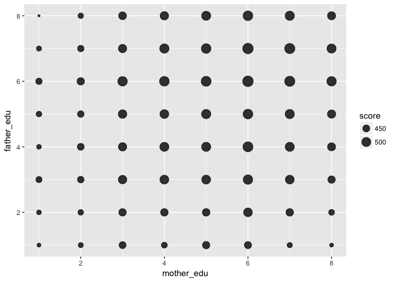

```r
parentsxperf = full_join(bsg %>% select(idcntry:idstud, bsbg07a, bsbg07b),
                         std_perf %>% select(idcntry:idstud, total))
parentsxperf %>%
  select(mother_edu = bsbg07a, father_edu = bsbg07b, score = total) %>%
  mutate(family_edu = (mother_edu + father_edu) / 2) %>%
  filter(!is.na(mother_edu) & !is.na(father_edu) & !is.na(score)) -> parentsxperf

parentsxperf %>%
  group_by(mother_edu = mother_edu %>% as.numeric(), father_edu = father_edu %>% as.numeric()) %>%
  summarise(score = mean(score)) -> parentsxperf_plot
parentsxperf_plot %>%
  ggplot(aes(x = mother_edu, y = father_edu)) +
  geom_point(aes(size = score), alpha = 0.8)
```

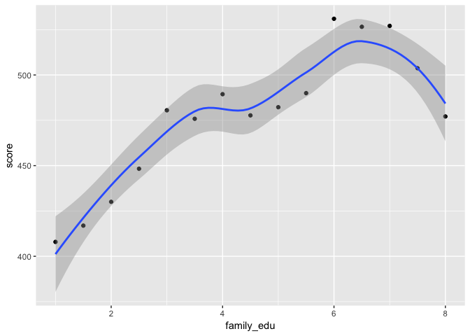

```r
parentsxperf %>%
  group_by(family_edu = family_edu %>% as.numeric()) %>%
  summarise(score = mean(score)) -> parentsxperf_plot
parentsxperf_plot %>%
  ggplot(aes(x = family_edu, y = score)) +
  geom_point() + geom_smooth()
```

```r
hchart(parentsxperf_plot, "line", hcaes(x = family_edu, y = score))
```

[interactive chart not shown]

```r
cor.test(parentsxperf$score, parentsxperf$mother_edu)
```

```
##
##  Pearson's product-moment correlation
##
## data:  parentsxperf$score and parentsxperf$mother_edu
## t = 94.922, df = 268770, p-value < 2.2e-16
## alternative hypothesis: true correlation is not equal to 0
## 95 percent confidence interval:
##  0.1764406 0.1837564
## sample estimates:
##      cor
## 0.180101
```

```r
# mother_fit = aov(score ~ mother_edu, data = parentsxperf)
# summary.aov(mother_fit)

cor.test(parentsxperf$score, parentsxperf$father_edu)
```

```
##
##  Pearson's product-moment correlation
##
## data:  parentsxperf$score and parentsxperf$father_edu
## t = 77.569, df = 268770, p-value < 2.2e-16
## alternative hypothesis: true correlation is not equal to 0
## 95 percent confidence interval:
##  0.1442746 0.1516702
## sample estimates:
##       cor
## 0.1479745
```

```r
# father_fit = aov(score ~ father_edu, data = parentsxperf)
# summary.aov(father_fit)

cor.test(parentsxperf$score, parentsxperf$family_edu)
```

```
##
##  Pearson's product-moment correlation
##
## data:  parentsxperf$score and parentsxperf$family_edu
## t = 96.066, df = 268770, p-value < 2.2e-16
## alternative hypothesis: true correlation is not equal to 0
## 95 percent confidence interval:
##  0.1785414 0.1858515
## sample estimates:
##      cor
## 0.182199
```

```r
family_fit = aov(score ~ family_edu, data = parentsxperf)
summary.aov(family_fit)
```

```
##                 Df    Sum Sq  Mean Sq F value Pr(>F)
## family_edu       1 9.475e+07 94752769    9229 <2e-16 ***
## Residuals   268771 2.760e+09    10267
## ---
## Signif. codes:  0 '***' 0.001 '**' 0.01 '*' 0.05 '.' 0.1 ' ' 1
```

با توجه به مقدار بسیار کم p-value می توان گفت فرض تاثیر نداشتن این دو روی یکدیگر رد می شود و فرض صورت سوال درست بوده است. همچنین این فرضیه برای مادر و پدر به طور جداگانه و در نهایت در کل بررسی شده است.

۳. امکانات رفاهی در خانه موجب پیشرفت تحصیلی می گردد.

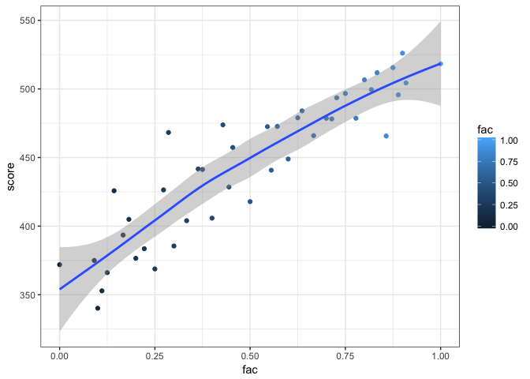

```r
facxperf = full_join(bsg %>% select(idcntry:idstud, bsbg06a:bsbg06k),
                           std_perf %>% select(idcntry:idstud, total))

facxperf %>%
  select(idcntry:idstud, score = total, bsbg06a:bsbg06k) %>%
  gather(key = "bsbg", value = "val", colnames(.)[7:ncol(.)]) -> facxperf

facxperf %>%
  drop_na() %>%
  group_by(idcntry, idbook, idschool, idclass, idstud, score) %>%
  summarise(fac = 2 - mean(val)) -> facxperf

facxperf %>%
  ungroup() %>%
  select(score, fac) %>%
  group_by(fac) %>%
  summarise(score = mean(score)) -> facxperf_plot

ggplot(facxperf_plot, aes(x = fac, y = score)) +
  geom_point(aes(color = fac)) +
  geom_smooth() + theme_bw()
```

```r
hchart(facxperf_plot, "line", hcaes(x = fac, y = score))
```

[interactive chart not shown]

```r
cor.test(facxperf$fac, facxperf$score)
```

```
##
##  Pearson's product-moment correlation
##
## data:  facxperf$fac and facxperf$score
## t = 161.48, df = 277300, p-value < 2.2e-16
## alternative hypothesis: true correlation is not equal to 0
## 95 percent confidence interval:
##  0.2897608 0.2965649
## sample estimates:
##       cor
## 0.2931666
```

با توجه به مقدار بسیار کم p-value می توان گفت فرض تاثیر نداشتن این دو روی یکدیگر رد می شود و فرض صورت سوال درست بوده است.

۴. محیط آرام مدرسه نقش مهمی در پیشرفت تحصیلی دارد.

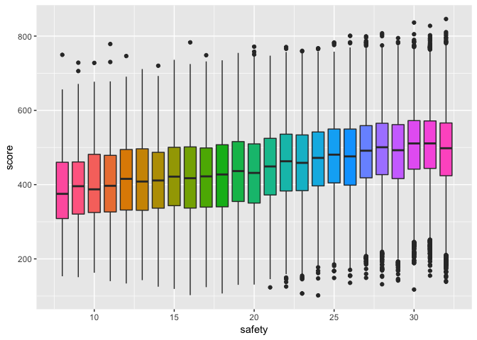

```r
schenvxperf = full_join(bsg %>% select(idcntry:idstud, bsbg16a:bsbg16i),
                        std_perf %>% select(idcntry:idstud, total))
schenvxperf %>%
  drop_na() %>%
  select(idcntry:idstud, score = total, bsbg16a:bsbg16i) %>%
  mutate(safety = bsbg16a + bsbg16b + bsbg16c + bsbg16d + bsbg16e + bsbg16f + bsbg16h + bsbg16i) -> schenvxperf

ggplot(schenvxperf, aes(x = safety, y = score)) +
  geom_boxplot(aes(fill = safety %>% as.character())) + guides(fill = FALSE)
```

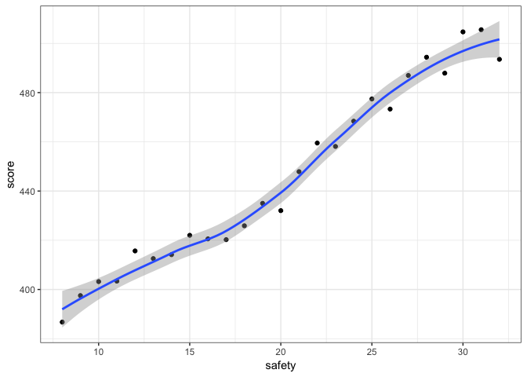

```r
schenvxperf %>%
  group_by(safety) %>%
  summarise(score = mean(score)) -> schenvxperf_plot
ggplot(data = schenvxperf_plot, aes(x = safety, y = score)) +
  geom_point() +
  geom_smooth() +
  theme_bw()
```

```r
hchart(schenvxperf_plot, "line",hcaes(x = safety, y = score))
```

[interactive chart not shown]

```r
cor.test(schenvxperf$score, schenvxperf$safety)
```

```
##
##  Pearson's product-moment correlation
##
## data:  schenvxperf$score and schenvxperf$safety
## t = 114.16, df = 257180, p-value < 2.2e-16
## alternative hypothesis: true correlation is not equal to 0
## 95 percent confidence interval:
##  0.2159361 0.2232929
## sample estimates:
##       cor
## 0.2196176
```

با توجه به مقدار بسیار کم p-value می توان گفت فرض تاثیر نداشتن این دو روی یکدیگر رد می شود و فرض صورت سوال درست بوده است.

۵. معلمان با تحصیلات بالاتر یا تجربه بیشتر دانش آموزان موفق تری تربیت می کنند.

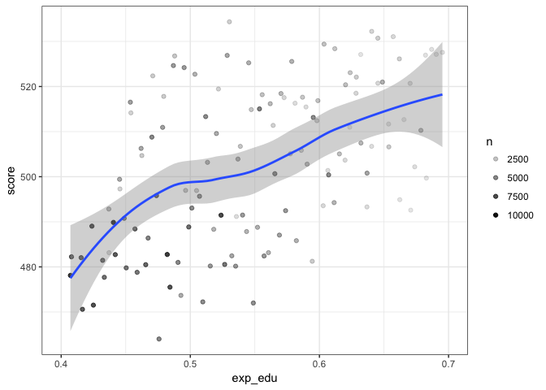

```r
# math ---------------
teacherxperf_math = full_join(bst %>% select(idcntry:idtealin),
                          std_perf %>% select(idcntry:idstud, math))
teacherxperf_math = full_join(teacherxperf_math, btm %>% select(idcntry:idlink, btbg01, btbg04))

teacherxperf_math %>%
  drop_na() %>%
  mutate(exp = btbg01 / max(btbg01) / 2, edu = btbg04 / max(btbg04) / 2) %>%
  mutate(exp_edu = exp + edu) %>%
  select(score = math, exp_edu) -> teacherxperf_math

# science ---------------
teacherxperf_sci = full_join(bst %>% select(idcntry:idtealin),
                              std_perf %>% select(idcntry:idstud, science))
teacherxperf_sci = full_join(teacherxperf_sci, bts %>% select(idcntry:idlink, btbg01, btbg04))

teacherxperf_sci %>%
  drop_na() %>%
  mutate(exp = btbg01 / max(btbg01) / 2, edu = btbg04 / max(btbg04) / 2) %>%
  mutate(exp_edu = exp + edu) %>%
  select(score = science, exp_edu) -> teacherxperf_sci

# both ---------------
teacherxperf = rbind(teacherxperf_math, teacherxperf_sci)
teacherxperf %>%
  ungroup() %>%
  group_by(exp_edu) %>%
  filter(n() > 1000) %>%
  summarise(score = mean(score), n = n()) -> teacherxperf_plot

ggplot(data = teacherxperf_plot, aes(x = exp_edu, y = score)) +
  geom_point(aes(alpha = n)) +
  geom_smooth() +
  xlim(0.4, 0.7) +
  theme_bw()
```

```r
hchart(teacherxperf_plot, "line", hcaes(x = exp_edu, y = score))
```

[interactive chart not shown]

```r
cor.test(teacherxperf$score, teacherxperf$exp_edu)
```

```
##
##  Pearson's product-moment correlation
##
## data:  teacherxperf$score and teacherxperf$exp_edu
## t = 130.36, df = 606640, p-value < 2.2e-16
## alternative hypothesis: true correlation is not equal to 0
## 95 percent confidence interval:
##  0.1626227 0.1675184
## sample estimates:
##       cor
## 0.1650716
```

در این جا برای تشخیص تحصیلات بالاتر و تجربه ی بیشتر معلمان، معیاری از این دو تعریف شده به صورتی که جمع مقدارهای نرمالایز شده ی این دو است. (میزان تحصیلات/تجربه، هر یک به صورت عددی بین ۰ و ۰.۵ درآمده است که معیاری از تحصیلات/تجربه با توجه به بیشترین مقدار ممکن است.) با توجه به مقدار بسیار کم p-value می توان گفت فرض تاثیر نداشتن تحصیلات/تجربه و موفقیت روی هم رد می شود و فرض صورت سوال درست بوده است.

۶. پسران در کاربرد هندسه قوی تر هستند.

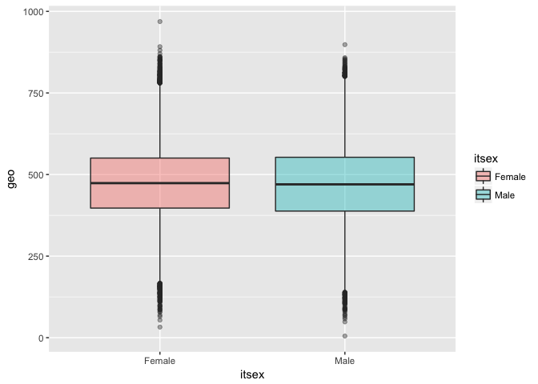

```r
genxgeo = full_join(std_perf %>% select(idcntry:idstud, bsmgeo01:bsmgeo05),
                     bsg %>% select(idcntry:idstud, itsex, bsbg01))

genxgeo %>%
  filter(itsex == bsbg01) %>%
  rowwise() %>%
  mutate(geo = mean(c(bsmgeo01:bsmgeo05))) %>%
  select(itsex, geo) %>%
  mutate(itsex = ifelse(itsex == 1, "Female", "Male")) %>%
  ungroup() -> genxgeo

ggplot(genxgeo, aes(x = itsex, y = geo, fill = itsex)) +
  geom_boxplot(alpha = 0.4)
```

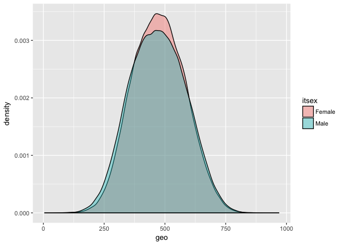

```r
ggplot(genxgeo, aes(x = geo,fill = itsex)) +
  geom_density(alpha = 0.4)
```

```r
genxgeo %>% group_by(itsex) %>% summarize(geo = mean(geo)) -> genxgeo_plot
hchart(genxgeo_plot, "bar", hcaes(x = itsex, y = geo))
```

[interactive chart not shown]

```r
t.test(geo ~ itsex, data = genxgeo, alt = "greater")
```

```
##
##  Welch Two Sample t-test
##
## data:  geo by itsex
## t = 8.6293, df = 277230, p-value < 2.2e-16
## alternative hypothesis: true difference in means is greater than 0
## 95 percent confidence interval:
##  2.933997      Inf
## sample estimates:
## mean in group Female   mean in group Male
##             474.6358             471.0108
```

با استفاده از t.test در مقایسه ی میانگین این دو گروه، فرض ما مبنی براینکه هندسه ی پسرها قوی تر بوده رد شده است.

۷. تغذیه دانش آموزان نقش اساسی در یادگیری آنها دارد.

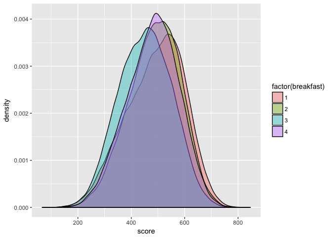

```r
breakfastxperf = full_join(bsg %>% select(idcntry:idstud, bsbg12),
                           std_perf %>% select(idcntry:idstud, total))
breakfastxperf %>%
  select(breakfast = bsbg12, score = total) %>%
  filter(!is.na(breakfast) & !is.na(score)) -> breakfastxperf

breakfastxperf %>%
  ggplot(aes(x = score, fill = factor(breakfast))) +
  geom_density(alpha = 0.4)
```

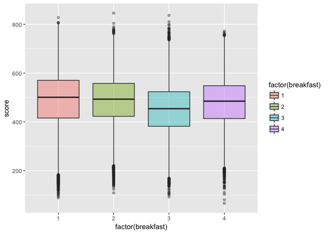

```r
breakfastxperf %>%
  ggplot(aes(x = factor(breakfast), y = score)) +
  geom_boxplot(aes(fill = factor(breakfast)), alpha = 0.4)
```

```r
breakfastxperf %>%
  group_by(breakfast) %>%
  summarize(score = mean(score)) -> breakfastxperf_plot

hchart(breakfastxperf_plot, "bar", hcaes(x = breakfast, y = score))
```

[interactive chart not shown]

```r
cor.test(breakfastxperf$score, breakfastxperf$breakfast)
```

```
##
##  Pearson's product-moment correlation
##
## data:  breakfastxperf$score and breakfastxperf$breakfast
## t = -52.408, df = 276080, p-value < 2.2e-16
## alternative hypothesis: true correlation is not equal to 0
## 95 percent confidence interval:
##  -0.10294207 -0.09555518
## sample estimates:
##      cor
## -0.09925
```

با توجه به مقدار بسیار کم p-value می توان گفت فرض تاثیر نداشتن این دو روی یکدیگر رد می شود و فرض صورت سوال درست بوده است.

۸. مدارس با امکانات بیشتر دارای عملکرد بهتری می باشند.

۹. علت افت تحصیلی عدم مشارکت در کلاس است.

۱۰. دانش آموزان ایرانی در استدلال قوی تر از کاربرد هستند.

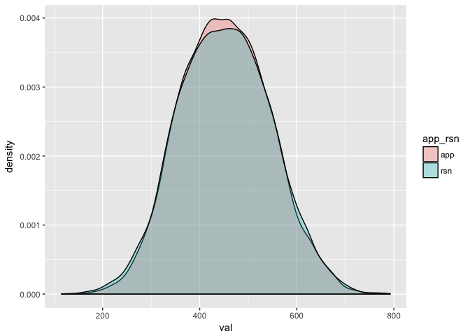

```r
bsa %>%
  filter(idcntry == 364) -> iran_bsa

iran_bsa %>%
  rowwise() %>%
  mutate(app = mean(c(bsmapp01:bsmapp05)),
         rsn = mean(c(bsmrea01:bsmrea05)), course = "math") -> appxrsn_math
iran_bsa %>%
  rowwise() %>%
  mutate(app = mean(c(bssapp01:bssapp05)),
         rsn = mean(c(bssrea01:bssrea05)), course = "science") -> appxrsn_sci

rbind(appxrsn_sci, appxrsn_math) -> appxrsn

appxrsn %>%
  select(idcntry:idstud, app, rsn) %>%
  gather(key = "app_rsn", value = "val", colnames(.)[6:ncol(.)]) -> appxrsn

ggplot(appxrsn, aes(val)) +
  geom_density(aes(fill = app_rsn), alpha = 0.3)
```

```r
#appxrsn_plot %>% group_by(app_rsn) %>% summarise(val = mean(val)) -> appxrsn_plot
#hchart(appxrsn_plot, "bar", hcaes(y = val, x = app_rsn))

t.test(val ~ factor(app_rsn), paired = TRUE, appxrsn)
```

```
##
##  Paired t-test
##
## data:  val by factor(app_rsn)
## t = 2.0996, df = 12259, p-value = 0.03578
## alternative hypothesis: true difference in means is not equal to 0
## 95 percent confidence interval:
##  0.03900292 1.13553334
## sample estimates:
## mean of the differences
##               0.5872681
```

سه گزاره جالب کشف کنید و ادعای خود را ثابت نمایید.

دانش آموزان مهاجر بلندپروازترند.

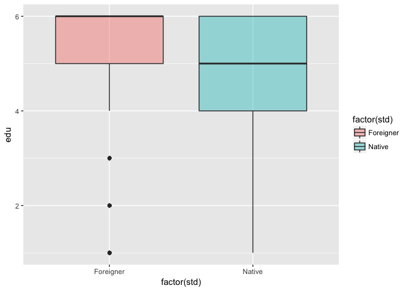

```r
bsg %>% select(bsbg08, bsbg09a, bsbg09b, bsbg10a) -> emg

emg %>%
  drop_na() %>%
  filter(bsbg09a != 3 & bsbg09b != 3) %>%
  mutate(std = ifelse(bsbg10a == 1, "Native", "Foreigner")) %>%
  mutate(edu = bsbg08, mother = bsbg09a, father = bsbg09b) %>%
  mutate(m = ifelse(mother == 1, "Native", "Foreigner")) %>%
  mutate(f = ifelse(father == 1, "Native", "Foreigner")) %>%
  select(edu, mother, father, std, m, f) -> emg

ggplot(emg, aes(y = edu, x = factor(std))) +
  geom_boxplot(aes(fill = factor(std)), alpha = 0.4)
```

```r
emg %>% group_by(std) %>% summarize(mean_edu = mean(edu)) -> emg_plot
hchart(emg_plot, "bar", hcaes(y = mean_edu, x = std))
```

[interactive chart not shown]

```r
t.test(edu ~ factor(std), emg, alt = "greater")
```

```
##
##  Welch Two Sample t-test
##
## data:  edu by factor(std)
## t = 49.014, df = 37891, p-value < 2.2e-16
## alternative hypothesis: true difference in means is greater than 0
## 95 percent confidence interval:
##  0.4003387       Inf
## sample estimates:
## mean in group Foreigner    mean in group Native
##                 5.05895                 4.64471
```

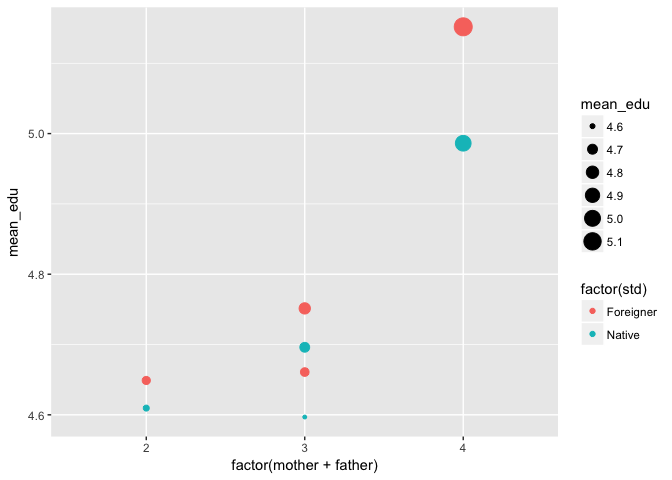

```r
emg %>% group_by(mother, father, std) %>%
  summarise(mean_edu = mean(edu)) -> emg_plot

ggplot(emg_plot, aes(x = factor(mother + father), y = mean_edu)) +
  geom_point(aes(color = factor(std), size = mean_edu))
```

```r
t.test(edu ~ factor(m), emg, alt = "greater")
```

```
##
##  Welch Two Sample t-test
##
## data:  edu by factor(m)
## t = 57.557, df = 95819, p-value < 2.2e-16
## alternative hypothesis: true difference in means is greater than 0
## 95 percent confidence interval:
##  0.3689206       Inf
## sample estimates:
## mean in group Foreigner    mean in group Native
##                4.989578                4.609804
```

```r
t.test(edu ~ factor(f), emg, alt = "greater")
```

```
##
##  Welch Two Sample t-test
##
## data:  edu by factor(f)
## t = 54.135, df = 88132, p-value < 2.2e-16
## alternative hypothesis: true difference in means is greater than 0
## 95 percent confidence interval:
##  0.3554071       Inf
## sample estimates:
## mean in group Foreigner    mean in group Native
##                4.982482                4.615938
```

```r
test = aov(edu ~ factor(mother + father), emg)
summary.aov(test)
```

```
##                             Df Sum Sq Mean Sq F value Pr(>F)
## factor(mother + father)      2   7482    3741    1737 <2e-16 ***
## Residuals               256351 552035       2
## ---
## Signif. codes:  0 '***' 0.001 '**' 0.01 '*' 0.05 '.' 0.1 ' ' 1
```

با توجه به مدرکی که دانش آموزان می خواهند در آینده بگیرند، میزان بلندپرواز بودن آن ها مشخص شده است اول نسل اول مهاجران بررسی شده است که با توجه به آزمون بلندپروازترند. سپس برای نسل دوم آن ها با توجه به این که پدر مهاجر بوده و یا مادر دوباره این گزاره بررسی شده است که در هر حالت نتیجه ی به دست آمده این است که این دانش آموزان از لحاظ تحصیلات اهداف بزرگتری دارند.

دانش آموزان معلمان خانم نتیجه ی بهتری می گیرند.

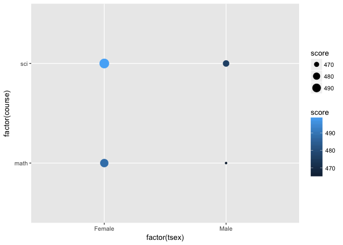

```r
teacherxperf_math = full_join(bst %>% select(idcntry:idtealin), std_perf %>% select(idcntry:idstud, math))
teacherxperf_math = full_join(teacherxperf_math, btm %>% select(idcntry:idlink, btbg02))
teacherxperf_math %>%
  drop_na() %>%
  mutate(tsex = ifelse(btbg02 == 1, "Female", "Male")) %>%
  mutate(score = math, course = "math") %>%
  select(score, tsex, course) -> teacherxperf_math


teacherxperf_sci = full_join(bst %>% select(idcntry:idtealin), std_perf %>% select(idcntry:idstud, science))
teacherxperf_sci = full_join(teacherxperf_sci, bts %>% select(idcntry:idlink, btbg02))
teacherxperf_sci %>%
  drop_na() %>%
  mutate(tsex = ifelse(btbg02 == 1, "Female", "Male")) %>%
  mutate(score = science, course = "sci") %>%
  select(score, tsex, course) -> teacherxperf_sci

teacherxperf = rbind(teacherxperf_math, teacherxperf_sci)

teacherxperf %>%
  group_by(tsex, course) %>%
  summarize(score = mean(score)) -> teacherxperf_plot

ggplot(teacherxperf_plot, aes(x = factor(tsex), y = factor(course))) +
  geom_point(aes(color = score, size = score))
```

```r
hchart(teacherxperf_plot, "bar", hcaes(x = tsex, y = score))
```

[interactive chart not shown]

```r
t.test(score ~ factor(tsex), teacherxperf, alt = "greater")
```

```
##
##  Welch Two Sample t-test
##
## data:  score by factor(tsex)
## t = 86.031, df = 483700, p-value < 2.2e-16
## alternative hypothesis: true difference in means is greater than 0
## 95 percent confidence interval:
##  23.32318      Inf
## sample estimates:
## mean in group Female   mean in group Male
##             495.0280             471.2502
```

تعداد تمرین بیشتر در هفته باعث افت دانش آموزان می شود.

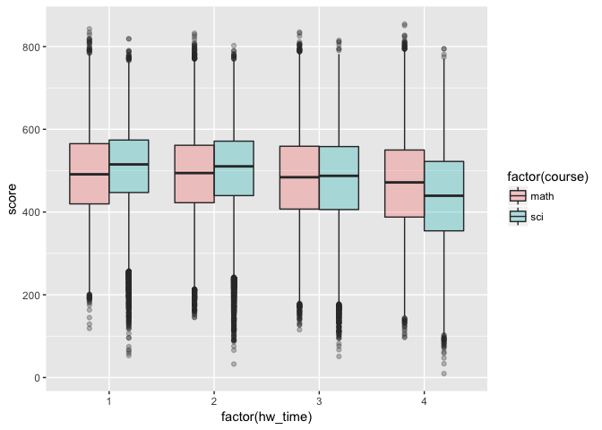

```r
full_join(bsg %>% select(idcntry:idstud, bsbm25aa, bsbs25ab), # math, science
          std_perf %>% select(idcntry:idstud, math, science)) -> hwxperf

hwxperf %>%
  filter(!is.na(bsbm25aa)) %>%
  mutate(hw_time = 5 - bsbm25aa, score = math, course = "math") %>%
  filter(hw_time != 0) %>%
  select(hw_time, score, course) -> hwxperf_math

hwxperf %>%
  filter(!is.na(bsbs25ab)) %>%
  mutate(hw_time = 5 - bsbs25ab, score = science, course = "sci") %>%
  filter(hw_time != 0) %>%
  select(hw_time, score, course) -> hwxperf_sci

hwxperf = rbind(hwxperf_math, hwxperf_sci)

ggplot(hwxperf, aes(x = factor(hw_time), y = score)) +
  geom_boxplot(aes(fill = factor(course)), alpha = 0.3)
```

```r
hwxperf %>% group_by(hw_time) %>% summarise(score = mean(score)) -> hwxperf_plot
hchart(hwxperf_plot, "bar", hcaes(x = hw_time, y = score))
```

[interactive chart not shown]

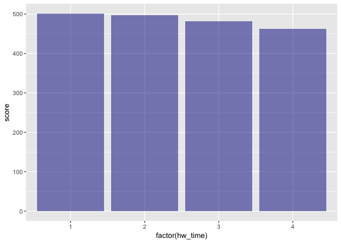

```r
ggplot(hwxperf_plot, aes(x = factor(hw_time), y = score)) +
  geom_bar(stat = "identity", alpha = 0.5, fill = "dark blue")
```

```r
cor.test(hwxperf$score, hwxperf$hw_time)
```

```
##
##  Pearson's product-moment correlation
##
## data:  hwxperf$score and hwxperf$hw_time
## t = -93.618, df = 460260, p-value < 2.2e-16
## alternative hypothesis: true correlation is not equal to 0
## 95 percent confidence interval:
##  -0.1395322 -0.1338621
## sample estimates:
##        cor
## -0.1366983
```

```r
hwxperf %>% filter(hw_time == 1 | hw_time == 4) -> hwxperf
t.test(score ~ hw_time, hwxperf, alt = "greater")
```

```
##
##  Welch Two Sample t-test
##
## data:  score by hw_time
## t = 78.168, df = 139060, p-value < 2.2e-16
## alternative hypothesis: true difference in means is greater than 0
## 95 percent confidence interval:
##  38.15517      Inf
## sample estimates:
## mean in group 1 mean in group 4
##        501.2542        462.2788
```

اگر کسانی را که هیچ گاه تمرین ندارند در نظر نگیریم، همان طور که در نمودارها نیز پیداست، افزایش تعداد تمرین در هفته نتیجه ی عکس می دهد. اول با استفاده از cor.test بررسی می کنیم که آیا این دو عامل روی هم تاثیر دارند یا خیر. سپس دو نمونه از این چهار نمونه را باهم مقایسه می کنیم و می بینیم که گزاره ی گفته شده صحیح است.